# Lab 3

Parker Davis

2023-02-01

# Tasks

## Task 1

Getting the Working Direcotry

```r
getwd()
```

```
## [1] "C:/RPACKAGES/FALL224753davi0607/MATH 4753 Labs/Lab3"
```

## Task 2

This is where I read in the SPRUCE data:

```r
dird="C:\\RPACKAGES\\FALL224753davi0607\\MATH 4753 Labs\\Lab3\\"

myread=function(csv){
  fl=paste(dird,csv,sep="")
  read.table(fl,header=TRUE,sep=",")
}

spruce.df=myread("SPRUCE.csv")#MS pg478


#First six lines:
head(spruce.df)
```

```
##   BHDiameter Height
## 1       18.9   20.0
## 2       16.6   18.8
## 3       15.5   16.8
## 4       15.5   16.9
## 5       19.4   20.2
## 6       13.7   16.3
```

## Task 3

### Initial Scatter Plot

This is the initial scatter plot of the data (x=BHDiameter, y=Height)

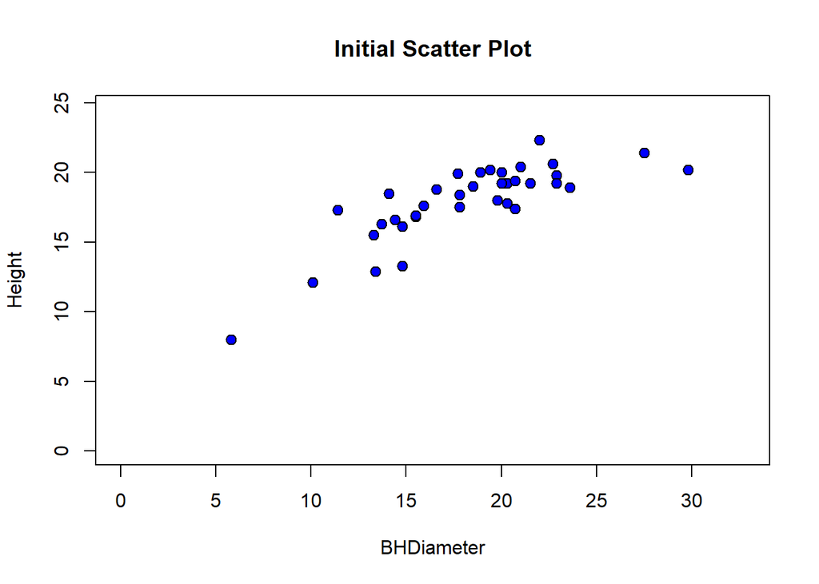

```r
with(spruce.df,
  plot(Height~BHDiameter,bg="Blue",pch=21,ylim=c(0,1.1*max(Height)),
      xlim=c(0,1.1*max(BHDiameter)), main = "Initial Scatter Plot", cex = 1.2))
```

### Trendscatter Plots (f=0.5,0.6,0.7)

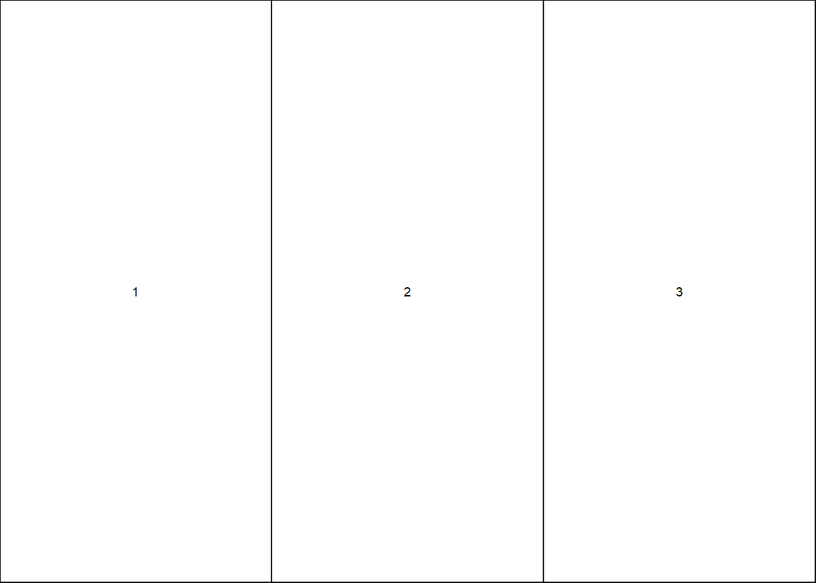

```r
#Load in the s20x package
library(s20x)

#Create the layout
layout(matrix(1:3, nr=1, nc = 3, byrow = TRUE))

layout.show(3)
```

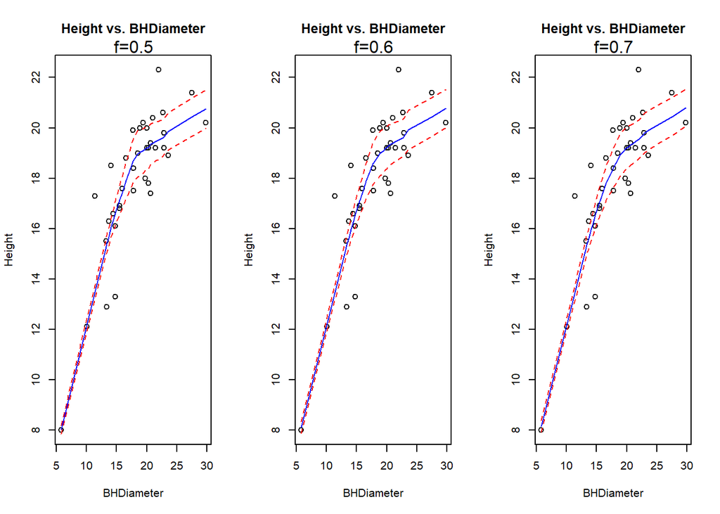

```r
#Create the trendscatter plots
trendscatter(Height~BHDiameter,f=0.5, data=spruce.df, main = "Height vs. BHDiameter")
mtext("f=0.5", side = 3)
trendscatter(Height~BHDiameter,f=0.6, data=spruce.df, main = "Height vs. BHDiameter")
mtext("f=0.6", side = 3)
trendscatter(Height~BHDiameter,f=0.7, data=spruce.df, main = "Height vs. BHDiameter")
mtext("f=0.7", side = 3)
```

### Straight Line Relationship Plot

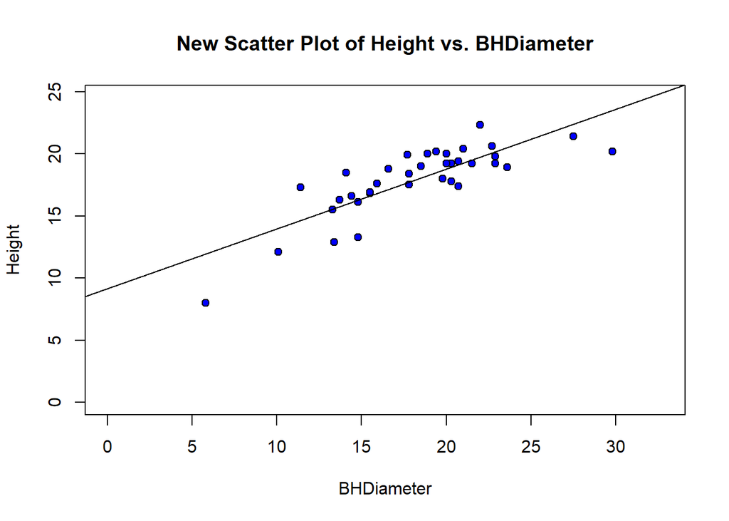

```r
# Making a linear model
spruce.lm=with(spruce.df, lm(Height~BHDiameter))

#Making the new scatter plot
with(spruce.df,
     plot(Height~BHDiameter,bg="Blue",pch=21,ylim=c(0,1.1*max(Height)),xlim=c(0,1.1*max(BHDiameter)), main = "New Scatter Plot of Height vs. BHDiameter")
)


#Plotting a least squares regression line
abline(spruce.lm)
```

For this graph, I don’t think a straight line is appropriate! When plotted against the data, you can pretty clearly see a curve in the data from the leftmost data point to the rightmost data point. When I look at the smoother curve plots, every regression line has some sort of a curve in it, which leads me to believe that a curved best fit line would be better accustomed to this data set versus a straight line.